# R Notebook

# 16S Data Analysis

```r
library(ggpubr)
library(phyloseq)
library(ggplot2)
library(tidyr)
library(dplyr)
library(MiscMetabar)
library(ggVennDiagram)
library(tidyverse)
library(tibble)
library(breakaway)
```

```r
#Create Phyloseq Object
otu_table_data <- read.csv("/Users/cmdb/qb25-answers/DADA2_Subset_Attempt1_files/OTU_Table.csv", row.names = 1)
metadata_table_data <- read.csv("/Users/cmdb/qb25-answers/DADA2_Subset_Attempt1_files/Metadata_Table.csv", row.names = 1)
tax_table_data <- read.csv("/Users/cmdb/qb25-answers/DADA2_Subset_Attempt1_files/OTU_Taxonomy_Table.csv", row.names = 1)

PS <- phyloseq(
  otu_table(as.matrix(otu_table_data), taxa_are_rows = TRUE),
  sample_data(metadata_table_data),
  tax_table(as.matrix(tax_table_data)))

PS_genus <- tax_glom(PS, taxrank = "Genus")
PS_phylum <- tax_glom(PS, taxrank = "Phylum")
```

Here I will use the built in shannon diversity and simpsom diversity measurements from the Phyloseq package.

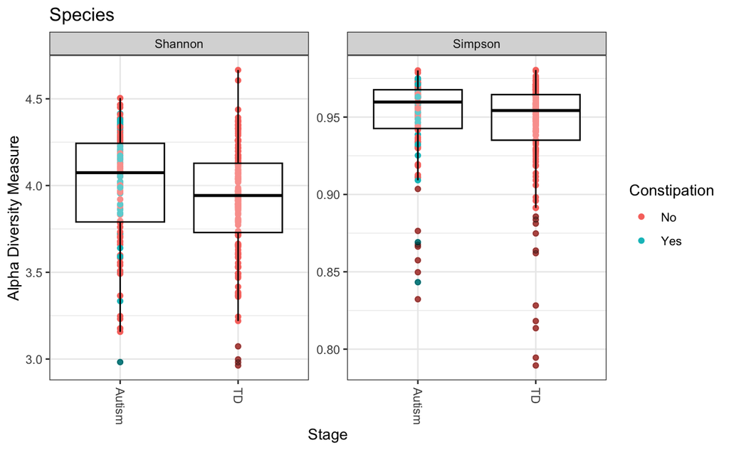

```r
theme_set(theme_bw())
plot_richness(PS, x="Stage", measures=c("Shannon", "Simpson"), color="Constipation") +
  geom_boxplot(alpha = 0.3, color = "black") +
  theme(legend.position="right") +
  labs(title = "Species")
```

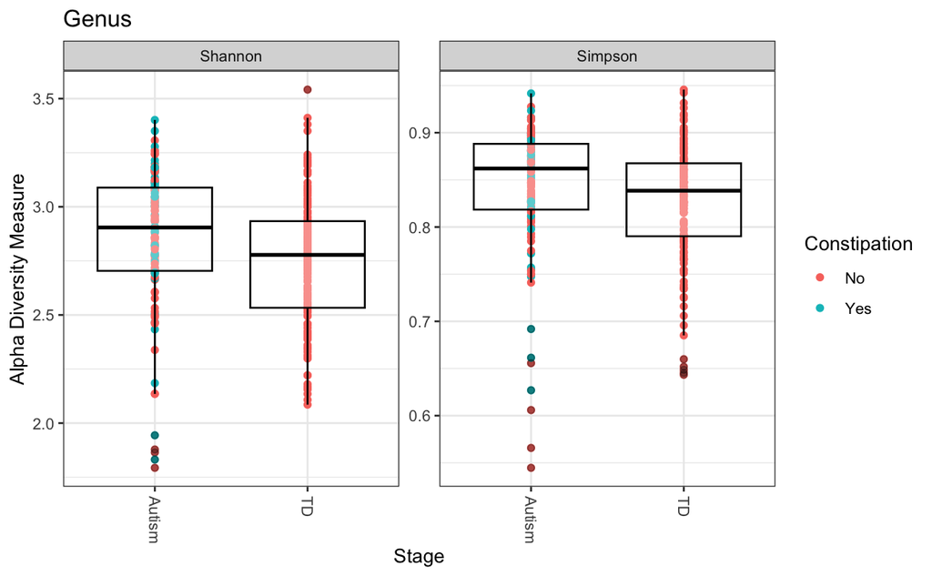

```r
plot_richness(PS_genus, x="Stage", measures=c("Shannon", "Simpson"), color="Constipation") +
  geom_boxplot(alpha = 0.3, color = "black") +
  theme(legend.position="right") +
  labs(title = "Genus")
```

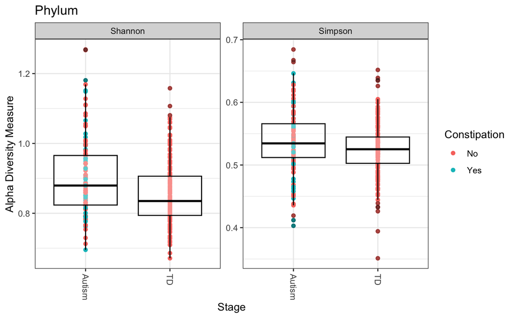

```r
plot_richness(PS_phylum, x="Stage", measures=c("Shannon", "Simpson"), color="Constipation") +
 geom_boxplot(alpha = 0.3, color = "black") +
  theme(legend.position="right") +
  labs(title = "Phylum")
```

It would be nice to add in some statistics. But by eye it looks like the analyses could be similar.

Now I’ll try with just genus/phylum count:

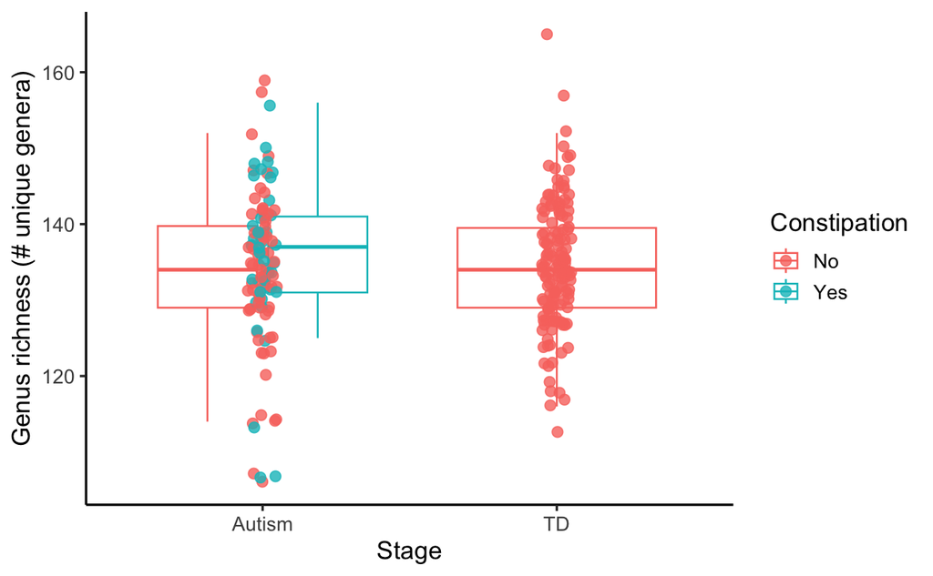

```r
# Extract OTU table
otu_table_genus <- as(otu_table(PS_genus), "matrix")
otu_table_phylum <- as(otu_table(PS_phylum), "matrix")

# Sum down columns → number of genera/phyla per sample
genus_richness <- colSums(otu_table_genus > 0)
phylum_richness <- colSums(otu_table_phylum > 0)

# Add Genus/PhylumRichness to sample_data(PS_genus)
sample_data(PS_genus)$GenusRichness <- genus_richness[sample_names(PS_genus)]
sample_data(PS_phylum)$PhylumRichness <- phylum_richness[sample_names(PS_phylum)]

# PLot
ggplot(sample_data(PS_genus), aes(x = Stage, y = GenusRichness, color = Constipation)) +
  geom_boxplot(outlier.shape = NA) +
  geom_jitter(width = 0.05, size = 2.5, alpha = 0.8) +
  labs(x = "Stage", y = "Genus richness (# unique genera)") +
  theme_classic(base_size = 14)
```

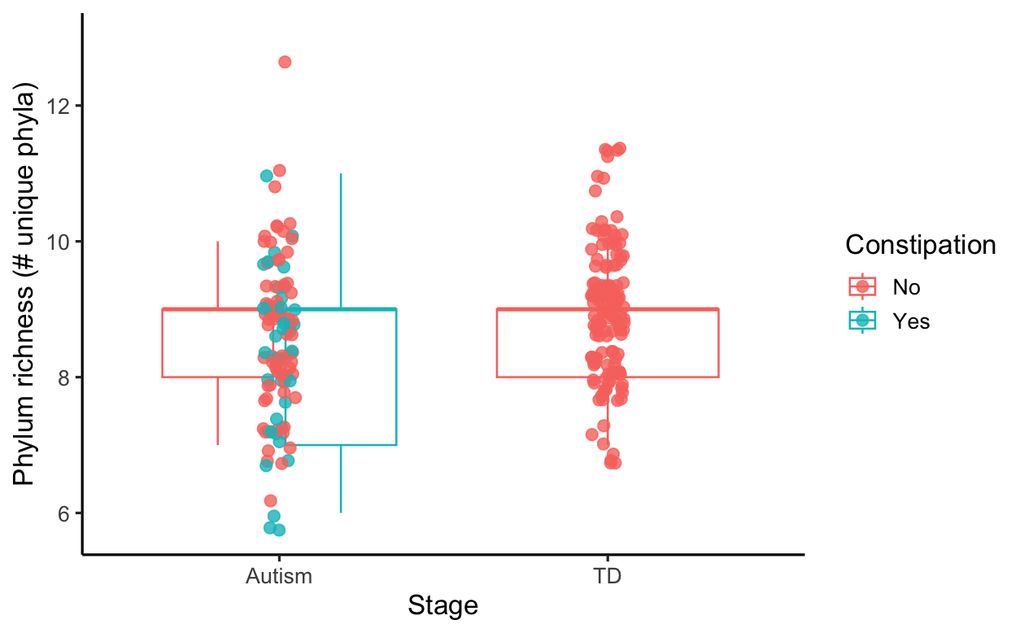

```r
ggplot(sample_data(PS_phylum), aes(x = Stage, y = PhylumRichness, color = Constipation)) +
  geom_boxplot(outlier.shape = NA) +
  geom_jitter(width = 0.05, size = 2.5, alpha = 0.8) +
  labs(x = "Stage", y = "Phylum richness (# unique phyla)") +
  theme_classic(base_size = 14)
```

Again these look like they could be similar to the author’s original figures just by eye, but I need to add statistical analysis to be sure. Now I’ll try to recreate the venn diagram they have of unique OTUs across groups.

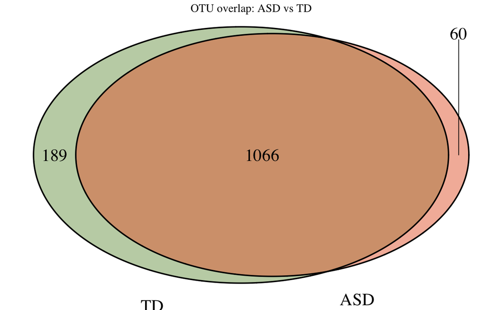

```r
library(VennDiagram)
library(grid)  # for grid.newpage()

# get list of OTUs from ASD and TD groups
ASD_OTUs <- otu_table_data %>%
  select(starts_with("B")) %>%
  filter(rowSums(. > 0) > 0) %>%
  rownames()

TD_OTUs <- otu_table_data %>%
  select(starts_with("A")) %>%
  filter(rowSums(. > 0) > 0) %>%
  rownames()

venn.plot <- venn.diagram(
  x = list(
    ASD = ASD_OTUs,
    TD    = TD_OTUs
  ),
  filename = NULL,  # draw to R graphics device instead of file
  #fill = c("#E8C2B1", "#C1CBB4"),
  fill = c("#E86A3C", "#7FA35A"),
  alpha = 0.5,
  cex = 1.5,
  cat.cex = 1.5,
  cat.pos = c(-20, 20),
  cat.dist = 0.05,
  main = "OTU overlap: ASD vs TD"
)

grid.newpage()
grid.draw(venn.plot)
```

This is not the same… While the number of total OTUs adds up to be the same as in the original figure, the subgroup totals are not the same. I am genuinely not sure why… It could be another artifact of rarification maybe?

Now I will construct a relative abundance stacked bar chart. They did not do this exact analysis, but I want it for comparison purposes with the metagenomic data. I am going to filter out rare and low abundance OTUs for easy viewing.

```r
# filter out rare and low abundant taxa
# Counts are already proportional (all samples have 31757)
PS_relabund  = transform_sample_counts(PS, function(x) x / sum(x) )
PS_relabund_genus  = transform_sample_counts(PS_genus, function(x) x / sum(x) )
PS_relabund_phylum  = transform_sample_counts(PS_phylum, function(x) x / sum(x) )
#Keep OTUs that are at least 1% of the relative abundance of each sample for at least (for 1 sample change to 0.003) (for 3 samples change to 0.01)
wh0 = genefilter_sample(PS_relabund, filterfun_sample(function(x) x > 0.01), A=0.003*nsamples(PS_relabund))
PS_relabund_filt = prune_taxa(wh0, PS_relabund)

wh1 = genefilter_sample(PS_relabund_genus, filterfun_sample(function(x) x > 0.01), A=0.003*nsamples(PS_relabund))
PS_relabund_filt_genus = prune_taxa(wh1, PS_relabund_genus)

wh2 = genefilter_sample(PS_relabund_phylum, filterfun_sample(function(x) x > 0.01), A=0.003*nsamples(PS_relabund))
PS_relabund_filt_phyla = prune_taxa(wh2, PS_relabund_phylum)
```

```r
# Check that taxa are filtered out
ntaxa(PS_relabund); ntaxa(PS_relabund_filt)
```

```
[1] 1322
[1] 165
```

[figure not shown]

```r
p<- plot_bar(PS_relabund_filt_genus, x = "Sample", y = "Abundance", fill = "Genus", facet_grid = "Stage")
p + geom_bar(aes(color=Genus, fill=Genus), stat="identity", position="stack") +
  theme_minimal()
```

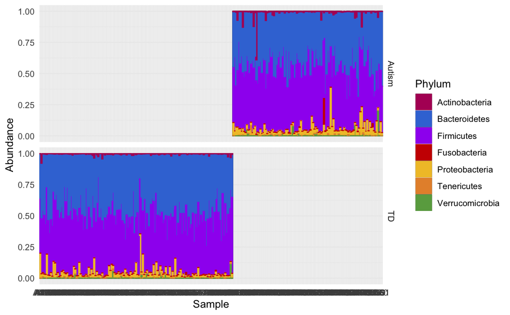

```r
phylum_colors <- c(
  "Actinobacteria"  = "#B31265",
  "Verrucomicrobia" = "#6AA84F",
  "Bacteroidetes"   = "#3C78D8",
  "Proteobacteria"  = "#F1C232",
  "Firmicutes"      = "purple",
  "Fusobacteria"    = "#CC0000",
  "Tenericutes"     = "#E69138",
  "Lentisphaerae"   = "#0FA3B1",
  "ZBacteria_Other"  = "#999999"
)


p<- plot_bar(PS_relabund_filt_phyla, x = "Sample", y = "Abundance", fill = "Phylum", facet_grid = "Stage") +
  scale_color_manual(values = phylum_colors)
p + geom_bar(aes(color=Phylum, fill=Phylum), stat="identity", position="stack") +
  theme_minimal() +
  scale_fill_manual(values = phylum_colors) +
  scale_color_manual(values = phylum_colors)
```

Now I will try to recreate the PCoA analysis they performed. They use “unweighted unifract distance” but I am not sure how they did that without generating a taxonomic tree (this slot of my phyloseq is currently empty). I could try to make one from scratch - but for now I will just use bray curtis dissimilarity for my distance.

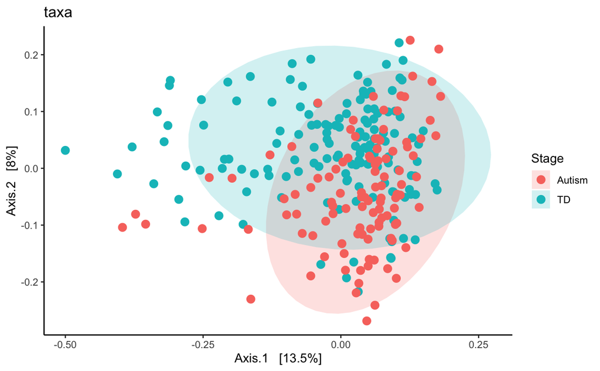

```r
PS_relabund_filt.ord <- ordinate(PS_relabund_filt, "PCoA")
PCoA1 = plot_ordination(PS_relabund_filt, PS_relabund_filt.ord, type="samples", color="Stage", title="taxa")
PCoA1 +
  stat_ellipse(aes(fill = Stage), geom = "polygon", alpha = 0.2, color = NA) +
  geom_point(size = 3) +
  theme_classic()
```

This looks pretty similar to the PCoA/Bray they did in their supplemental data. It is not the one they chose to display in their main figure because it is not as striking of a result. Regardless, you can see a bit more heterogeneity in the TD group and a bit more clustering in the Autism group. I would hesitate to say that the groups are truly separated, but the authors do not claim this either.

# Metagenomic Analysis

Rishi is working to re-process the metagenomic data using MetaSpades. This is not what they authors used… We don’t understand the analysis pipeline they claim to have used and they do a poor job of explaining it. Its not very reproducible :( <- sad face

```r
#Read in metagenomic data table
metagenomic1 <- read.table("/Users/cmdb/qb25-answers/DADA2_Subset_Attempt1_files/Figure_Attempt_files/Bracken on collection 104: Report/SRR7057628.tabular", sep = "\t", header = TRUE, check.names = FALSE)
metagenomic1 <- metagenomic1 %>%
  select(name, taxonomy_id, new_est_reads) %>%
  mutate(Sample = "A54")

metagenomic2 <- read.table("/Users/cmdb/qb25-answers/DADA2_Subset_Attempt1_files/Figure_Attempt_files/Bracken on collection 104: Report/SRR7057635.tabular", sep = "\t", header = TRUE, check.names = FALSE)
metagenomic2 <- metagenomic2 %>%
  select(name, taxonomy_id, new_est_reads) %>%
  mutate(Sample = "A76")

metagenomic3 <- read.table("/Users/cmdb/qb25-answers/DADA2_Subset_Attempt1_files/Figure_Attempt_files/Bracken on collection 104: Report/SRR7057636.tabular", sep = "\t", header = TRUE, check.names = FALSE)
metagenomic3 <- metagenomic3 %>%
  select(name, taxonomy_id, new_est_reads) %>%
  mutate(Sample = "A78")

metagenomic4 <- read.table("/Users/cmdb/qb25-answers/DADA2_Subset_Attempt1_files/Figure_Attempt_files/Bracken on collection 104: Report/SRR7057637.tabular", sep = "\t", header = TRUE, check.names = FALSE)
metagenomic4 <- metagenomic4 %>%
  select(name, taxonomy_id, new_est_reads) %>%
  mutate(Sample = "A87")

metagenomic5 <- read.table("/Users/cmdb/qb25-answers/DADA2_Subset_Attempt1_files/Figure_Attempt_files/Bracken on collection 104: Report/SRR7057638.tabular", sep = "\t", header = TRUE, check.names = FALSE)
metagenomic5 <- metagenomic5 %>%
  select(name, taxonomy_id, new_est_reads) %>%
  mutate(Sample = "A89")

metagenomic6 <- read.table("/Users/cmdb/qb25-answers/DADA2_Subset_Attempt1_files/Figure_Attempt_files/Bracken on collection 104: Report/SRR7057651.tabular", sep = "\t", header = TRUE, check.names = FALSE)
metagenomic6 <- metagenomic6 %>%
  select(name, taxonomy_id, new_est_reads) %>%
  mutate(Sample = "B127")

metagenomic7 <- read.table("/Users/cmdb/qb25-answers/DADA2_Subset_Attempt1_files/Figure_Attempt_files/Bracken on collection 104: Report/SRR7057671.tabular", sep = "\t", header = TRUE, check.names = FALSE)
metagenomic7 <- metagenomic7 %>%
  select(name, taxonomy_id, new_est_reads) %>%
  mutate(Sample = "B143")

metagenomic8 <- read.table("/Users/cmdb/qb25-answers/DADA2_Subset_Attempt1_files/Figure_Attempt_files/Bracken on collection 104: Report/SRR7057675.tabular", sep = "\t", header = TRUE, check.names = FALSE)
metagenomic8 <- metagenomic8 %>%
  select(name, taxonomy_id, new_est_reads) %>%
  mutate(Sample = "B152")

metagenomic9 <- read.table("/Users/cmdb/qb25-answers/DADA2_Subset_Attempt1_files/Figure_Attempt_files/Bracken on collection 104: Report/SRR7057676.tabular", sep = "\t", header = TRUE, check.names = FALSE)
metagenomic9 <- metagenomic9 %>%
  select(name, taxonomy_id, new_est_reads) %>%
  mutate(Sample = "B156")

metagenomic10 <- read.table("/Users/cmdb/qb25-answers/DADA2_Subset_Attempt1_files/Figure_Attempt_files/Bracken on collection 104: Report/SRR7057677.tabular", sep = "\t", header = TRUE, check.names = FALSE)
metagenomic10 <- metagenomic10 %>%
  select(name, taxonomy_id, new_est_reads) %>%
  mutate(Sample = "B2")

metagenomic_long <- bind_rows(metagenomic1, metagenomic2, metagenomic3, metagenomic4, metagenomic5, metagenomic6, metagenomic7, metagenomic8, metagenomic9, metagenomic10)

metagenomic <- metagenomic_long %>%
  select(name, taxonomy_id, Sample, new_est_reads) %>%
  pivot_wider(
    names_from  = Sample,          # samples become columns
    values_from = new_est_reads,   # fill values with read counts
    values_fill = 0                # fill missing sample-taxons with 0
  )

# Identify sample columns (everything except Genus and Species columns)
sample_cols <- !(names(metagenomic) %in% c("name", "taxonomy_id"))

#make sure values are all numeric
#metagenomic[, sample_cols] <- lapply(metagenomic[, sample_cols], as.numeric)

#OTU matrix
otu_samples <- as.matrix(metagenomic[, sample_cols])

#create concatenated names to stand in for "OTU names"
rownames(otu_samples) <- make.unique(paste(metagenomic$name))
otu_metagenomic <- otu_table(otu_samples, taxa_are_rows = TRUE)

#Tax table (Genus + Species)
tax_tab <- as.matrix(metagenomic$name)
rownames(tax_tab) <- rownames(otu_samples)
colnames(tax_tab) <- c("Species")

#Version as data frame
tax_tab_df <- as.data.frame(tax_tab, stringsAsFactors = FALSE)
```

To try to get the remaining taxonomies (likely some fungal) I am going to use a tool (recommended by ChatGTP - but implemented through developer’s documentation) called “Taxize” to access NCBI’s taxonomy. This will also hopefully help with alternative taxonomies between databases.

```r
library(taxize)

# Map Species -> taxonomy_id from the metagenomic table
taxid_map <- metagenomic %>%
  rename(Species = name) %>%
  select(Species, taxonomy_id) %>%   # <-- NOTE: taxonomy_id
  distinct()                         # one row per Species–taxonomy_id

# Join into your existing taxonomy table (which already has GTDB columns)
tax_tab_df <- tax_tab_df %>%
  left_join(taxid_map, by = "Species")
# Now tax_tab_df has a `taxonomy_id` column where available

ncbi_ids <- tax_tab_df %>%
  pull(taxonomy_id) %>%   # <-- taxonomy_id here
  unique() %>%
  na.omit() %>%
  as.character()

ncbi_class_list <- classification(ncbi_ids, db = "ncbi")
# This returns a named list: each element is a data.frame with
# columns: name, rank, id for that taxonomy_id
```

```r
#These steps came from ChatGTP - I tried for hours to get the output of Taxize into a table.
#I also tried multiple other avenues but I got stuck and here we are

### 4. Convert classification() list -> long data frame ----

classification_to_df <- function(x) {
  # keep only entries that are data.frames
  keep <- x[sapply(x, is.data.frame)]

  out <- do.call(rbind, lapply(names(keep), function(id) {
    cbind(
      taxonomy_id = id,     # <-- this will match your taxonomy_id column
      keep[[id]],
      stringsAsFactors = FALSE
    )
  }))

  rownames(out) <- NULL
  out
}

ncbi_tax_long <- classification_to_df(ncbi_class_list)
# columns: taxonomy_id, name, rank, id


### 5. Long → wide taxonomy table (one row per ncbi_id)
ncbi_tax_wide <- ncbi_tax_long %>%
  filter(rank %in% c("domain", "phylum", "class", "order",
                     "family", "genus", "species")) %>%
  distinct(taxonomy_id, rank, .keep_all = TRUE) %>%
  select(taxonomy_id, rank, name) %>%
  pivot_wider(
    names_from  = rank,
    values_from = name
  )

tax_tab_df<- tax_tab_df %>%
  mutate(taxonomy_id = as.character(taxonomy_id))

ncbi_tax_wide <- ncbi_tax_wide %>%
  mutate(taxonomy_id = as.character(taxonomy_id))

tax_tab_df <- tax_tab_df %>%
  left_join(ncbi_tax_wide, by = "taxonomy_id")
```

```r
rownames(tax_tab_df) <- tax_tab_df$Species

# Drop the OTU column
tax_tab_df$Species <- NULL
tax_tab_df$taxonomy_id <- NULL

tax_tab_df <- tax_tab_df %>%
  rename(
   Domain = domain,
    Phylum  = phylum,
    Class   = class,
    Order   = order,
    Family  = family,
    Genus   = genus,
    Species = species     # rename lowercase 'species'
  )

#Fix ordering problem
otu_ids <- taxa_names(otu_metagenomic)
tax_cols <- c("Domain", "Phylum", "Class", "Order", "Family", "Genus", "Species")
tax_taxonly <- tax_tab_df[, tax_cols, drop = FALSE]
tax_for_phy <- tax_taxonly[otu_ids, , drop = FALSE]

#Add Taxonomy Table
tax_metagenomic <- tax_table(as.matrix(tax_for_phy))


#Add Sample metadata
meta_16s <- as(sample_data(PS), "data.frame")   # from your 16S object
meta_mg  <- meta_16s[colnames(otu_samples), , drop = FALSE]
samp_metagenomic <- sample_data(meta_mg)

#Build phyloseq object
PS_metagenomic <- phyloseq(otu_metagenomic, tax_metagenomic, samp_metagenomic)
```

Okay so now the metagenomic phyloseq object is built. Lets start with just a simple richness graph to prove it’s working.

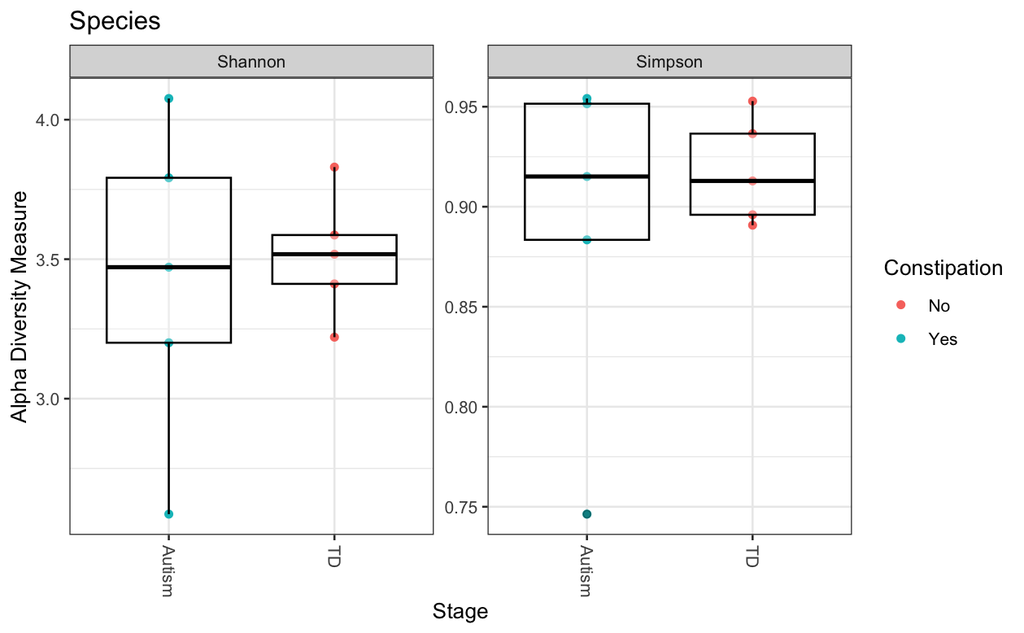

```r
otu <- otu_table(PS_metagenomic)

# convert to matrix, replace NA with 0, rebuild
otu_mat <- as.matrix(otu)
otu_mat[is.na(otu_mat)] <- 0

otu_metagenomic_clean <- otu_table(otu_mat, taxa_are_rows = taxa_are_rows(otu))

# rebuild a clean phyloseq object with the same tax + sample data
PS_metagenomic <- phyloseq(
  otu_metagenomic_clean,
  tax_table(PS_metagenomic),
  sample_data(PS_metagenomic)
)
PS_metagenomic_genus <- tax_glom(PS_metagenomic, taxrank = "Genus")
PS_metagenomic_phylum <- tax_glom(PS_metagenomic, taxrank = "Phylum")

theme_set(theme_bw())
plot_richness(PS_metagenomic, x="Stage", measures=c("Shannon", "Simpson"), color="Constipation") +
  geom_boxplot(alpha = 0.3, color = "black") +
  theme(legend.position="right") +
  labs(title = "Species")
```

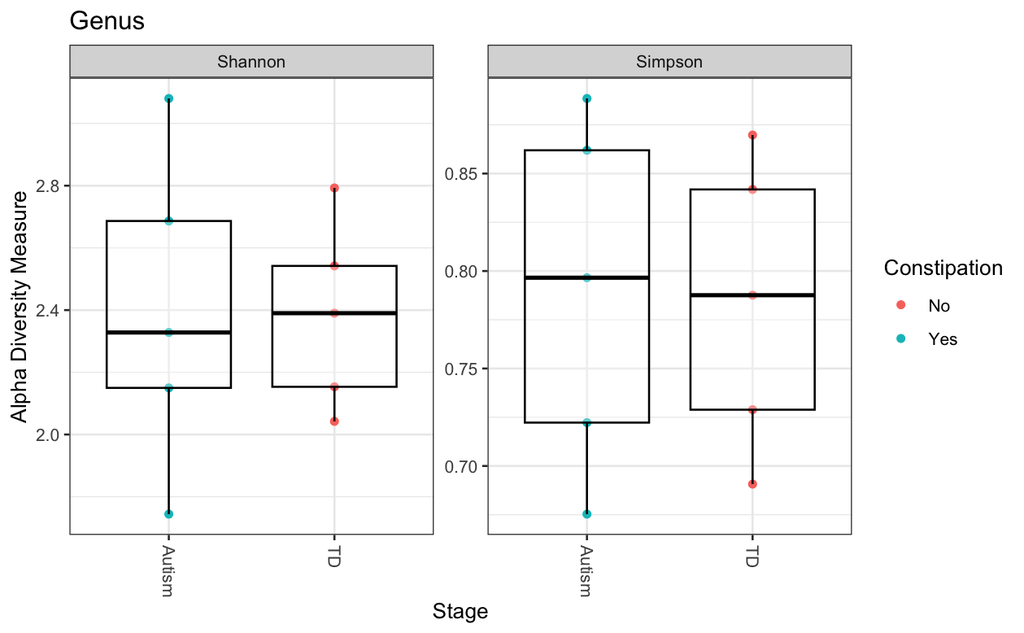

```r
plot_richness(PS_metagenomic_genus, x="Stage", measures=c("Shannon", "Simpson"), color="Constipation") +
  geom_boxplot(alpha = 0.3, color = "black") +
  theme(legend.position="right") +
  labs(title = "Genus")
```

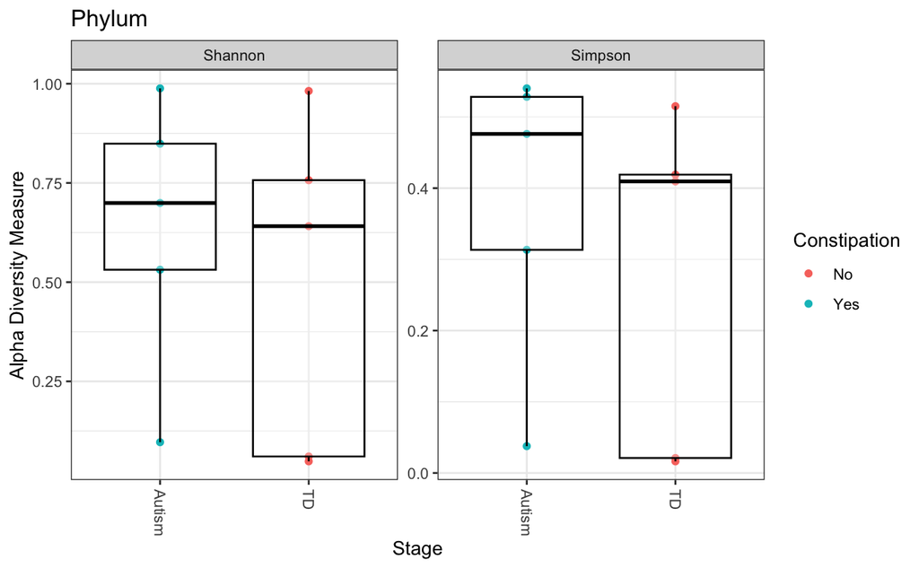

```r
plot_richness(PS_metagenomic_phylum, x="Stage", measures=c("Shannon", "Simpson"), color="Constipation") +
 geom_boxplot(alpha = 0.3, color = "black") +
  theme(legend.position="right") +
  labs(title = "Phylum")
```

Lets make that venn diagram again:

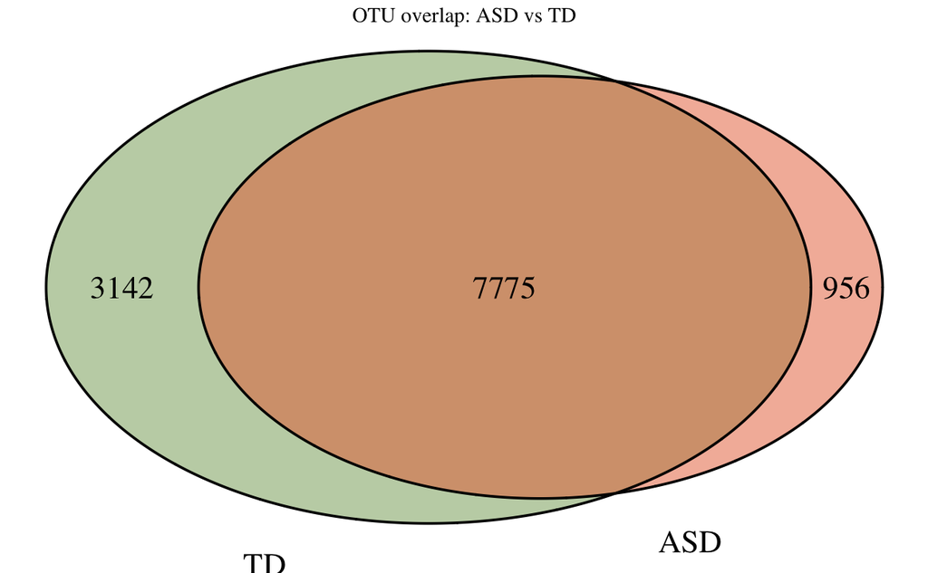

```r
# get list of OTUs from ASD and TD groups
ASD_OTUs_meta <- as.data.frame(otu_samples) %>%
  select(starts_with("B")) %>%
  filter(rowSums(. > 0) > 0) %>%
  rownames()

TD_OTUs_meta <- as.data.frame(otu_samples) %>%
  select(starts_with("A")) %>%
  filter(rowSums(. > 0) > 0) %>%
  rownames()

venn.plot <- venn.diagram(
  x = list(
    ASD = ASD_OTUs_meta,
    TD    = TD_OTUs_meta
  ),
  filename = NULL,  # draw to R graphics device instead of file
  #fill = c("#E8C2B1", "#C1CBB4"),
  fill = c("#E86A3C", "#7FA35A"),
  alpha = 0.5,
  cex = 1.5,
  cat.cex = 1.5,
  cat.pos = c(-20, 20),
  cat.dist = 0.05,
  main = "OTU overlap: ASD vs TD"
)

grid.newpage()
grid.draw(venn.plot)
```

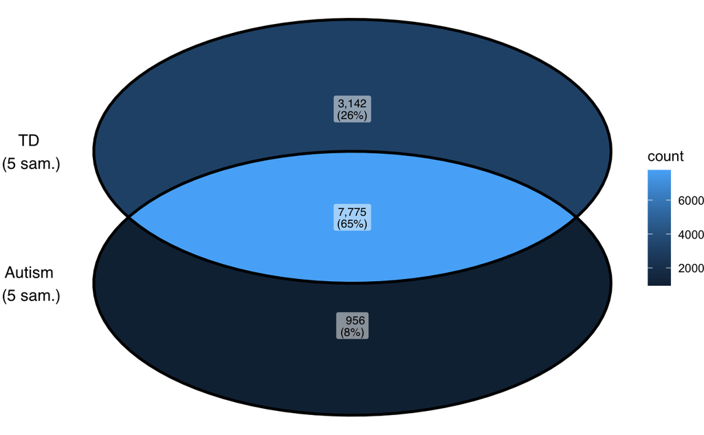

```r
ggvenn_pq(physeq = PS_metagenomic, fact = "Stage", type = "nb_taxa",
          set_name_size = 10,   # size of group labels
          label_size = 3) +     # size of intersection counts
  theme(text = element_text(hjust = 0.3)) +
  coord_cartesian(clip = "off")
```

```r
# filter out rare and low abundant taxa
# Counts are already proportional (all samples have 31757)
PS_meta_relabund  = transform_sample_counts(PS_metagenomic, function(x) x / sum(x) )
PS_meta_relabund_genus  = transform_sample_counts(PS_metagenomic_genus, function(x) x / sum(x) )
PS_meta_relabund_phylum  = transform_sample_counts(PS_metagenomic_phylum, function(x) x / sum(x) )
#Keep OTUs that are at least 1% of the relative abundance of each sample for at least (for 1 sample change to 0.003) (for 3 samples change to 0.01)
wh4 = genefilter_sample(PS_meta_relabund, filterfun_sample(function(x) x > 0.01), A=0.003*nsamples(PS_meta_relabund))
PS_meta_relabund_filt = prune_taxa(wh4, PS_meta_relabund)

wh5 = genefilter_sample(PS_meta_relabund_genus, filterfun_sample(function(x) x > 0.01), A=0.003*nsamples(PS_meta_relabund_genus))
PS_meta_relabund_filt_genus = prune_taxa(wh5, PS_meta_relabund_genus)

wh6 = genefilter_sample(PS_meta_relabund_phylum, filterfun_sample(function(x) x > 0.01), A=0.003*nsamples(PS_meta_relabund_phylum))
PS_meta_relabund_filt_phylum = prune_taxa(wh6, PS_meta_relabund_phylum)

# Check that taxa are filtered out
ntaxa(PS_meta_relabund); ntaxa(PS_meta_relabund_filt)
```

```
[1] 11880
[1] 67
```

These are using more updated taxonomies than the 16S data. For comparison I will have to “de-age” the metagenomic classifications so that our plots are comparable…

```r
#Extract taxonomy as a df
tax_meta <- as.data.frame(tax_table(PS_meta_relabund_filt_phylum))

#"De-age" meta names
tax_meta <- tax_meta %>%
  mutate(
    Phylum = case_when(
      Phylum == "Bacteroidota"       ~ "Bacteroidetes",
      Phylum == "Bacillota"          ~ "Firmicutes",
      Phylum == "Pseudomonadota"     ~ "Proteobacteria",
      Phylum == "Fusobacteriota"     ~ "Fusobacteria",
      Phylum == "Verrucomicrobiota"  ~ "Verrucomicrobia",
      Phylum == "Desulfobacterota_I" ~ "Proteobacteria",
      Phylum == "Actinomycetota" ~ "Actinobacteria",
      Phylum == "Lentisphaerota" ~ "Lentisphaerae",
      TRUE                           ~ Phylum
    )
  )

tax_table(PS_meta_relabund_filt_phylum) <- tax_table(as.matrix(tax_meta))

unique(as.data.frame(PS_meta_relabund_filt_phylum@tax_table)$Phylum)
```

```
[1] "Bacteroidetes"  "Firmicutes"     "Actinobacteria" "Proteobacteria" "Chordata"       "Uroviricota"
```

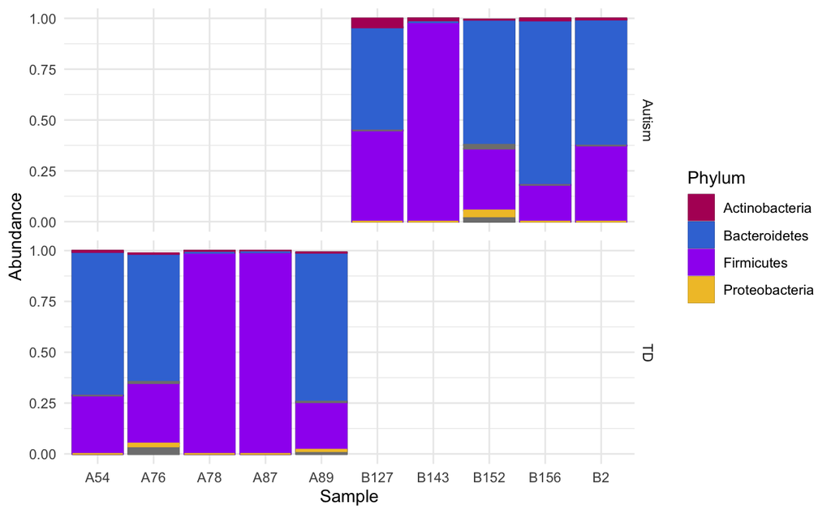

```r
p<- plot_bar(PS_meta_relabund_filt_phylum, x = "Sample", y = "Abundance", fill = "Phylum", facet_grid = "Stage") +
  scale_color_manual(values = phylum_colors)
p + geom_bar(aes(color=Phylum, fill=Phylum), stat="identity", position="stack") +
  theme_minimal() +
  scale_fill_manual(values = phylum_colors) +
  scale_color_manual(values = phylum_colors)
```

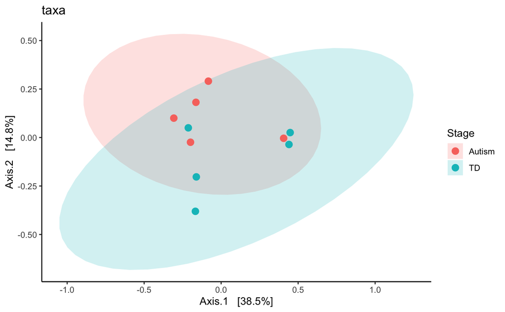

```r
PS_meta_relabund_filt.ord <- ordinate(PS_meta_relabund_filt, "PCoA")
PCoA2 = plot_ordination(PS_meta_relabund_filt, PS_meta_relabund_filt.ord, type="samples", color="Stage", title="taxa")
PCoA2 +
  stat_ellipse(aes(fill = Stage), geom = "polygon", alpha = 0.2, color = NA) +
  geom_point(size = 3) +
  theme_classic()
```